# Lab: Data I/O

36-600

Fall 2022

## Question 1

Download `simple.txt` from the Canvas site. It is in the `DATA` directory. Use an external viewer (your choice) to look at the file. Then apply an appropriate function to read the file’s contents into `R`. Show the names of the columns. Make sure the names are correct, and that there are eight columns. (Note: you may find that your first choice of function does not provide optimal results. If so, try another function. Note that `read_delim()` with a properly formatted regex might help here. If you use base `R` functionality, consider including the argument `stringsAsFactors=FALSE`.)

```r
# FILL ME IN
read.table("C:/Users/Jie Sing Yoo/Downloads/CMU Coursework/Overview of Statistical Learning and Modeling/R_labs/simple.txt",header=TRUE)
```

```
##       name       u       g       r       i       z       y redshift
## 1 galaxy.A 17.8313 16.9077 16.4431 16.2099 16.0613 15.8732 0.038356
## 2 galaxy.B 19.0731 17.7448 16.9789 16.5288 16.2551 15.9531 0.058309
## 3 galaxy.C 21.6380 21.0106 20.8286 20.6283 20.6552 20.5280 0.063701
## 4 galaxy.D 20.5474 19.5542 19.2387 19.0568 19.0887 18.9865 0.059006
## 5 galaxy.E 21.2378 20.6876 20.5661 20.4371 20.4799 20.4503 0.063202
## 6 galaxy.F 22.4627 21.4597 21.0484 20.8274 20.7639 20.6385 0.057773
## 7 galaxy.G 23.8221 22.8950 22.5779 22.3543 22.3225 22.2038 0.061548
## 8 galaxy.H 23.0491 22.1536 21.8791 21.6889 21.7044 21.6381 0.063769
## 9 galaxy.I 23.6742 23.0346 22.7857 22.6116 22.5813 22.5462 0.061427
```

## Question 2

Read in the data file from Question 1 but skip the header. Display the names that `R` gives to the columns. For `readr`, you may find sub-optimal results; if so, you would need to specify the column names as an argument. (You need not actually do that here.)

```r
# FILL ME IN
read.table("C:/Users/Jie Sing Yoo/Downloads/CMU Coursework/Overview of Statistical Learning and Modeling/R_labs/simple.txt",header=FALSE)
```

```
##          V1      V2      V3      V4      V5      V6      V7       V8
## 1      name       u       g       r       i       z       y redshift
## 2  galaxy.A 17.8313 16.9077 16.4431 16.2099 16.0613 15.8732 0.038356
## 3  galaxy.B 19.0731 17.7448 16.9789 16.5288 16.2551 15.9531 0.058309
## 4  galaxy.C  21.638 21.0106 20.8286 20.6283 20.6552  20.528 0.063701
## 5  galaxy.D 20.5474 19.5542 19.2387 19.0568 19.0887 18.9865 0.059006
## 6  galaxy.E 21.2378 20.6876 20.5661 20.4371 20.4799 20.4503 0.063202
## 7  galaxy.F 22.4627 21.4597 21.0484 20.8274 20.7639 20.6385 0.057773
## 8  galaxy.G 23.8221  22.895 22.5779 22.3543 22.3225 22.2038 0.061548
## 9  galaxy.H 23.0491 22.1536 21.8791 21.6889 21.7044 21.6381 0.063769
## 10 galaxy.I 23.6742 23.0346 22.7857 22.6116 22.5813 22.5462 0.061427
```

## Question 3

Read in the data file from Question 1 but only read in the first four lines, while retaining the header.

```r
# FILL ME IN
df = read.table("C:/Users/Jie Sing Yoo/Downloads/CMU Coursework/Overview of Statistical Learning and Modeling/R_labs/simple.txt",header=TRUE)
head(df,4)
```

```
##       name       u       g       r       i       z       y redshift
## 1 galaxy.A 17.8313 16.9077 16.4431 16.2099 16.0613 15.8732 0.038356
## 2 galaxy.B 19.0731 17.7448 16.9789 16.5288 16.2551 15.9531 0.058309
## 3 galaxy.C 21.6380 21.0106 20.8286 20.6283 20.6552 20.5280 0.063701
## 4 galaxy.D 20.5474 19.5542 19.2387 19.0568 19.0887 18.9865 0.059006
```

## Question 4

Download `planets_small.csv` from the Canvas site. It is in the `DATA` directory. Use an external viewer (your choice) to look at the file. Then apply an appropriate function to read the file’s contents into `R`. Note that here, you have one column that should be rendered as character strings (`pl_hostname`, the first column), while the rest should be rendered as factor variables. Thus you do not want to use the `stringsAsFactors` argument here, as it is too coarse. You need to explicitly specify the types of each column. (There’s an example of how to do this in the notes, with base `R` functionality! Or you can try using the argument `col_types` in `read_csv()`.)

```r
# FILL ME IN
read.csv("C:/Users/Jie Sing Yoo/Downloads/CMU Coursework/Overview of Statistical Learning and Modeling/R_labs/planets_small.csv",header=TRUE,colClasses=c("character","factor","factor","factor"))
```

```
##                pl_hostname pl_letter   pl_discmethod pl_pnum
## 1                   11 Com         b Radial Velocity       1
## 2                   11 UMi         b Radial Velocity       1
## 3                   14 And         b Radial Velocity       1
## 4                   14 Her         b Radial Velocity       1
## 5                 16 Cyg B         b Radial Velocity       1
## 6                   18 Del         b Radial Velocity       1
## 7    1RXS J160929.1-210524         b         Imaging       1
## 8                   24 Sex         b Radial Velocity       2
## 9                   24 Sex         c Radial Velocity       2
## 10 2MASS J01225093-2439505         b         Imaging       1
```

```r
#what if there are 10 or more columns?
         #rep("factor",3)
```

## Question 5

Download `students.txt` from the Canvas site. It is in the `DATA` directory. Use an external viewer (your choice) to look at the file. Then apply an appropriate function to read the file’s contents into `R`. Use an appropriate argument that ensures that each non-numerical column is treated as a vector of strings, and not a factor variable. (You may have done this back up in Question 1.) Show that you’ve done this by displaying the type of the variable the column `Last Name`. (Use `typeof()`.)

```r
# FILL ME IN
pd = read.table("C:/Users/Jie Sing Yoo/Downloads/CMU Coursework/Overview of Statistical Learning and Modeling/R_labs/students.txt",header=TRUE,stringsAsFactors = FALSE)
typeof(pd$Last.Name)
```

```
## [1] "character"
```

```r
pd
```

```
##   Last.Name First.Name Andrew.ID
## 1   Baggins      Bilbo  bilbobag
## 2       Bar        Foo     fbar1
## 3    Umlaut     Dieter   dumlaut
```

## Question 6

Download `emline.csv` from the Canvas site. It is in the `DATA` directory. Use an external viewer (your choice) to look at the file. Then apply an appropriate function to read the file’s contents into `R`. When you are done, show the mean and median values of the `sfr` column. Hint: if they are wildly different, you may need to adjust how you read in the data. Hint: look for numbers that represent missing data, and use an appropriate argument to tell `R` that those numbers should be converted to `NA`.

```r
# FILL ME IN
df = read.csv("C:/Users/Jie Sing Yoo/Downloads/CMU Coursework/Overview of Statistical Learning and Modeling/R_labs/emline.csv",header=TRUE,na.strings = c("-9999"," "))
mean(df$sfr,na.rm=TRUE)
```

```
## [1] -0.71412
```

```r
median(df$sfr,na.rm=TRUE)
```

```
## [1] -0.6436
```

```r
print(df)
```

```
##   O_II_3729 H_gamma  H_beta O_III_4959 O_III_5007 N_II_6548 H_ALPHA N_II_6584
## 1    1.5364  1.7004  0.3709    -0.0549     0.6216    0.4846  1.2458    0.5687
## 2    9.4411  2.7609  4.0603     0.5418     0.8290    0.7808 11.2330    4.2059
## 3   17.3146  3.3528  6.3293     0.7573     4.7597    1.0888 21.6571    3.5426
## 4    8.8070 -0.2765  1.4274     1.0690     1.7463    0.5824  7.5148    2.0032
## 5   17.3470  3.8775  2.6622     0.5714     3.2273    1.1112 13.9770    4.1352
## 6   37.8111  4.4961 10.0149     3.2715    11.7268    2.2371 39.9036    8.3394
## 7   55.3728  7.7921 13.7503     9.4787    28.0838    1.3237 38.2856    3.9767
## 8   24.0244  4.6931  8.4271     1.9320     6.4095    2.6659 35.1531   10.7334
## 9   31.8309  3.2743  7.0494     3.7526    12.1558    2.3935 31.8069    5.3516
##   S_II_6717 S_II_6731   mass     sfr
## 1   -0.4526    1.0754 9.9484      NA
## 2    1.8614    2.6442 9.9976      NA
## 3    2.5171    3.1083 9.8058 -0.7249
## 4    2.7998    0.7398 9.8352      NA
## 5    4.6136    2.3890 9.7140 -0.6436
## 6    9.9219    6.2621 9.6657 -0.4929
## 7    3.2716    4.6510 8.9972      NA
## 8    9.7281    5.5440 9.8578 -0.5099
## 9    8.5123   10.3885 9.8120 -1.1993
```

## Question 7

Download `students.csv` from the Canvas site. It is in the `DATA` directory. Use an external viewer (your choice) to look at the file. Then apply an appropriate function to read the file’s contents into `R`. Apply appropriate arguments or other function calls after the fact to ensure that the first three columns of the final data frame (or tibble) are character vectors, and the fourth column is a factor variable. (Simply print out the data frame or tibble; the variable type will be shown.) (Hint: if you use a `readr` function, then the argument `col_types` can be a single string with one letter for each column: “c” for a character vector, “d” for double, “i” for integer, “f” for factor, etc.). Hint: if using base `R`, it is simplest to start with `stringsAsFactors=FALSE` and then convert one column to a factor variable.

```r
# FILL ME IN
read.csv("C:/Users/Jie Sing Yoo/Downloads/CMU Coursework/Overview of Statistical Learning and Modeling/R_labs/students.csv",header=TRUE,stringsAsFactors=FALSE,colClasses=c("factor","character","character","character"),skip=6)
```

```
##   Last.Name First.Name Andrew.ID Vegetarian
## 1   Baggins      Bilbo  bilbobag          N
## 2       Bar        Foo     fbar1          Y
## 3    Umlaut     Dieter   dumlaut          N
```

## Question 8

Download `bolts.xls` from the Canvas site. It is in the `DATA` directory. If you cannot view the file with `Excel`, there are 100 rows and two columns: `Hour` and `Length`. Read the file into `R`, compute for average `Length` for each value of `Hour`, then plot that average versus `Hour`. (Remember: the variable before the “versus” is the $y$ variable.) Note that if you pass a two-column data frame to `plot()`, it will know what to do. Hint: perhaps `group_by()` and `summarize()` here.

```r
# FILL ME IN
library("readxl")
library("magrittr")
library("dplyr")
```

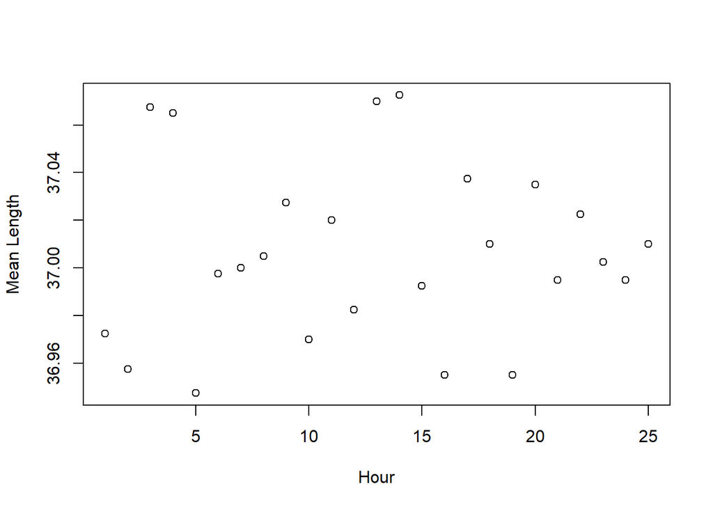

```r
df = read_excel("C:/Users/Jie Sing Yoo/Downloads/CMU Coursework/Overview of Statistical Learning and Modeling/R_labs/bolts.xls")

df %>% group_by(Hour) %>% summarize(Mean=mean(Length)) %>% plot(xlab='Hour',ylab='Mean Length')
```

## Question 9

Download `data.xlsx` from the Canvas site. It is in the `DATA` directory. Also in the `DATA` directory is `data.png`; download and open it. It is a screen shot of a portion of the data that indicates possibly problematic data. Read the file into `R` while properly dealing with these problematic data. Note that data actually exists in the field(s) marked “#########”; you need not actually do anything about that marker. Display just the four columns in which problematic data existed in the screen shot (use `select()`); those data should be replaced with `NA`.

```r
# FILL ME IN
#install.packages("dplyr")
library("dplyr")
pd = read_excel("C:/Users/Jie Sing Yoo/Downloads/CMU Coursework/Overview of Statistical Learning and Modeling/R_labs/data.xlsx",na='999')
pd %>% select(Sex,RaceEthnicity,ADHD,Presentation)
```

```
## # A tibble: 3 × 4
##     Sex RaceEthnicity  ADHD Presentation
##   <dbl>         <dbl> <dbl> <chr>
## 1     2             4     1 3
## 2    NA            NA    NA <NA>
## 3     2             1     0 4
```

```r
#tbl = read_excel("DATA/data.xlsx",na=c("999","999.00"))
```